# Uncertainty measures used in the benchmark

As a reminder, we consider two types of uncertainty measures:

- The **aleatoric uncertainty**, that conveys the **ambiguity** intrinsic to the data. In theory, this uncertainty can not be reduced with additional training data.
- The **epistemic uncertainty**, that conveys **novelty** within the data, and can be reduced with additional training data,

## 1. Aleatoric uncertainty

To estimate the aleatoric uncertainty, we will use an approach based on the information theory that we present below.

### 1.1 **Deterministic information gain**

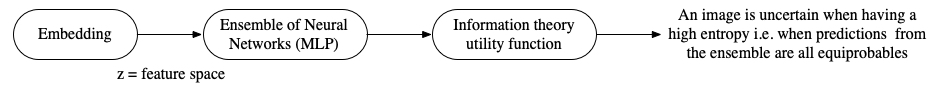

The **shannon entropy** on the averaged softmax probability distribution over the ensemble is computed as follow:

$ H(z) = -\sum^{N}_{i=1}{p_{i}(z)\log_{2} p_{i}(z)} $

with $z$ a data point in the feature space and $i$ the class index.

## 2. Epistemic uncertainty

### 2.1 **Deep ensemble**

The **deep ensemble** methods that consist in duplicating the Neural Network in order to estimate the variance of in the predictions probability with an ensemble of softmax probability distributions. With standardized datasets (MNIST), this approach was found to model the best the **epistemic uncertainty**,

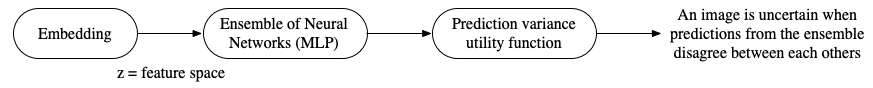

- The averaged **standard deviation over the classes** probability:

$ var(z) = \frac{1}{N}\sum^{N}_{i=1}{\underset{k \in ensemble}{std}p^{k}_{i}(z)} $

with $p^{k}_{i}$ the probability of class $i$ from the $k^{th}$ model in the ensembe.

### 2.2 **Density estimation** in the feature space with a deterministic model

The **density estimation** in the feature space with a deterministic model (the embedding). This approach aims at modelling the **epistemic uncertainty** with a smaller computational cost than the deep ensemble technique since it does not require to duplicate the models.

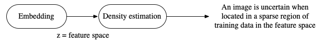

- The **Gaussian Mixture Model**, which assumes all the data points are generated from a mixture of a finite number of Gaussian distributions with unknown parameters. We use one component per class. The epistemic uncertainty is calculated using the weighted log probabilities for each sample.
- A **Gaussian Mixture Model per class**, in which we fit one GMM with 5 components per class.
- The **Density estimation** over the entire classes, using a gaussian kernel, a positive function controlled by the bandwidth parameter. Given this kernel form, the density estimate at a point within a group of points is given by:

$\phi_{K}(z) = \sum^{N}_{i=1} K(y- x_{i}; h)$

with: $K(x;h) \propto exp(-\frac{x^{2}}{2h^{2}})$

# Data importation and models declaration

```python
import numpy as np
import matplotlib.pyplot as plt
import pandas as pd


%load_ext autoreload
%autoreload 2

import sys
sys.path.append("..")
from common.utilities import Data
from common.figures import Figures
from common.metrics import PerformanceMetrics

from common.models import ModelUtilities
```

```
The autoreload extension is already loaded. To reload it, use:
  %reload_ext autoreload
```

```python
filepath = "./datasets/processed_data/consistent_card_data.pkl"
train, test, uncertain = Data.get_dataset(filepath = filepath)
(z_train, y_train), (z_test, y_test), z_uncertain = Data.dataframe2arrays(train, test, uncertain)
```

```
Dataset loaded...
Number of images:  350
Features:  name, class_label, uncertainty_label, group, X_PIL, X_array, X_mobilenet, y_onehot, y, z_ensemble
Labels:  king, nine, queen
Training set size:  150
Testing set size:  150
Uncertain pool size:  50
```

# Sanity check: how many training epochs do we need to reach convergence?

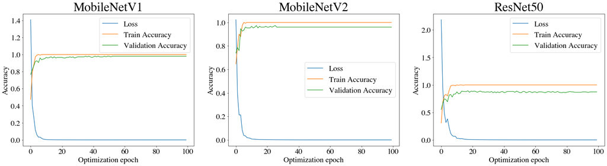

```python
Figures.check_convergence_mlp(z_train, y_train, z_test, y_test, num_classes = 10,  nb_epochs = 100, batch_size = 16)
```

**Observation**: 10 epochs is enough to reach convergence. A small number of epochs will also makes the interactive system train faster.

# Model fitting

Now, we are going to fit our list of models onto our training dataset and compute an accuracy on our test dataset.

```python
model_params = ModelUtilities.get_models_param(embeddings = ["MobileNetV1", "MobileNetV2", "ResNet50"],
                nb_mlp = [3],
                architecture = [(64,32)],
                epochs = [10],
                batch_sizes = [16],
                classes = ["nine", "queen", "king"])

models = ModelUtilities.get_models(model_params)
models
```

| name | embedding | n_tot_MLP | architecture | training_epochs | batch_size | classifier | model |
| --- | --- | --- | --- | --- | --- | --- | --- |
| GMM-MobileNetV1 | MobileNetV1 | 0 | None | None | None | True | <common.models.GMM object at 0x7fb0b351a670> |
| GaussianKernel-MobileNetV1 | MobileNetV1 | 0 | None | None | None | False | <common.models.GaussianDensity object at 0x7fb... |
| GMM-MobileNetV2 | MobileNetV2 | 0 | None | None | None | True | <common.models.GMM object at 0x7fb0cec65ca0> |
| GaussianKernel-MobileNetV2 | MobileNetV2 | 0 | None | None | None | False | <common.models.GaussianDensity object at 0x7fb... |
| GMM-ResNet50 | ResNet50 | 0 | None | None | None | True | <common.models.GMM object at 0x7fb0b351afd0> |
| GaussianKernel-ResNet50 | ResNet50 | 0 | None | None | None | False | <common.models.GaussianDensity object at 0x7fb... |
| DeepEnsemble-MobileNetV1-epochs=10 | MobileNetV1 | 3 | (64, 32) | 10 | 16 | True | <common.models.Ensemble object at 0x7fb0b351ad60> |
| MLP-MobileNetV1-epochs=10 | MobileNetV1 | 1 | (64, 32) | 10 | 16 | True | <common.models.MLP object at 0x7fb0b3547070> |
| DeepEnsemble-MobileNetV2-epochs=10 | MobileNetV2 | 3 | (64, 32) | 10 | 16 | True | <common.models.Ensemble object at 0x7fb0b357ef10> |
| MLP-MobileNetV2-epochs=10 | MobileNetV2 | 1 | (64, 32) | 10 | 16 | True | <common.models.MLP object at 0x7fb0b3575ee0> |
| DeepEnsemble-ResNet50-epochs=10 | ResNet50 | 3 | (64, 32) | 10 | 16 | True | <common.models.Ensemble object at 0x7fb0b41326a0> |
| MLP-ResNet50-epochs=10 | ResNet50 | 1 | (64, 32) | 10 | 16 | True | <common.models.MLP object at 0x7fb0aff8a9d0> |

```python
ModelUtilities.fit_models(models, z_train, y_train, verbose = False)
```

```python
models["accuracy"] = PerformanceMetrics.accuracy(models, z_train, y_train, z_test, y_test, verbose = False)
models["accuracy"]
```

```
name
GMM-MobileNetV1                       0.520000
GaussianKernel-MobileNetV1                 NaN
GMM-MobileNetV2                       0.493333
GaussianKernel-MobileNetV2                 NaN
GMM-ResNet50                          0.426667
GaussianKernel-ResNet50                    NaN
DeepEnsemble-MobileNetV1-epochs=10    0.980000
MLP-MobileNetV1-epochs=10             0.946667
DeepEnsemble-MobileNetV2-epochs=10    0.953333
MLP-MobileNetV2-epochs=10             0.940000
DeepEnsemble-ResNet50-epochs=10       0.866667
MLP-ResNet50-epochs=10                0.873333
Name: accuracy, dtype: float64
```

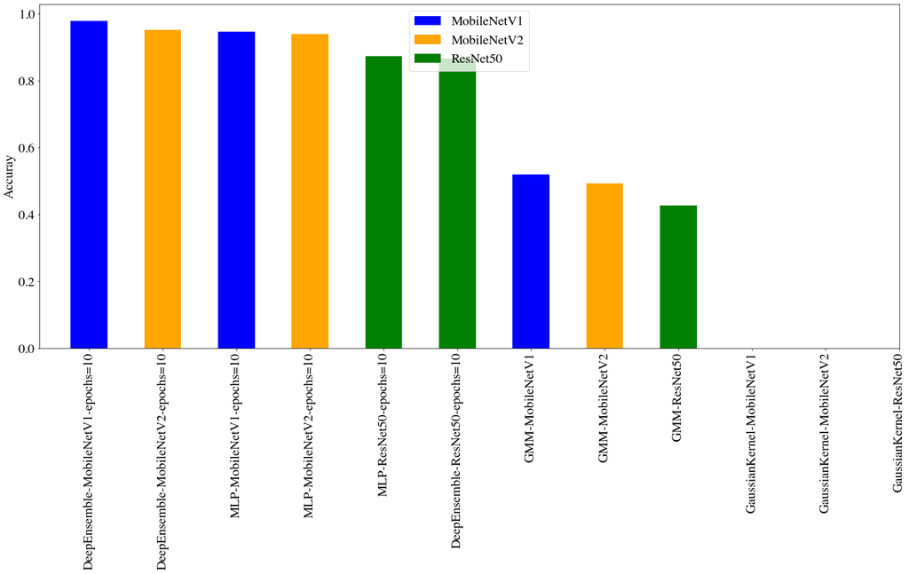

```python
Figures.accuracies(models)
```

**Observation**: In this case, the effect of the embedding seems less important than the type of model. All the cases in which a neural network architecture is used perform best than the density-based methods. We also suspect a problem in the initialization of the GMM leading to inconsistent values.

# Uncertainty on image data points

```python
all_data = pd.concat([test, uncertain])

iid = all_data.loc[all_data['uncertainty_label'] == "Classifiable"]
novel = all_data.loc[all_data['uncertainty_label'] == "Novel"]
ambiguous = all_data.loc[all_data['uncertainty_label'] == "Ambiguous"]

(z_novel, y_novel), (z_ambiguous, y_ambiguous), _ = Data.dataframe2arrays(novel, ambiguous, iid)
z_iid  = z_test
```

```python
values = PerformanceMetrics.uncertainty_classification(models, z_iid, z_uncertain, verbose=True)
```

```
GMM-MobileNetV1
GaussianKernel-MobileNetV1
GMM-MobileNetV2
GaussianKernel-MobileNetV2
GMM-ResNet50
GaussianKernel-ResNet50
DeepEnsemble-MobileNetV1-epochs=10
	aleatoric entropy
	epistemic std
MLP-MobileNetV1-epochs=10
	aleatoric entropy
DeepEnsemble-MobileNetV2-epochs=10
	aleatoric entropy
	epistemic std
MLP-MobileNetV2-epochs=10
	aleatoric entropy
DeepEnsemble-ResNet50-epochs=10
	aleatoric entropy
	epistemic std
MLP-ResNet50-epochs=10
	aleatoric entropy
```

We put the uncertainty values in a `pandas.DataFrame` normalize the values.

```python
uncertainty_values = pd.DataFrame({
    "Images": np.concatenate((test["X_PIL"].values, uncertain["X_PIL"].values)),
    "GroundTruth": np.concatenate((test["class_label"].values, uncertain["class_label"].values)),
    "UncertaintyLabel": np.concatenate((test["uncertainty_label"].values, uncertain["uncertainty_label"].values)),
    "Name": np.concatenate((test["name"].values, uncertain["name"].values)),
    })
z_iid = z_test


for model_name in values.keys():
    if type(values[model_name]["Uncertainties"]) == np.ndarray:
        uncertainty_values[model_name] = values[model_name]["Uncertainties"]
    else:
        uncertainty_values[model_name] = None


uncertainty_scaled = Data.normalize(uncertainty_values)
```

## Correlations between the uncertainty measures

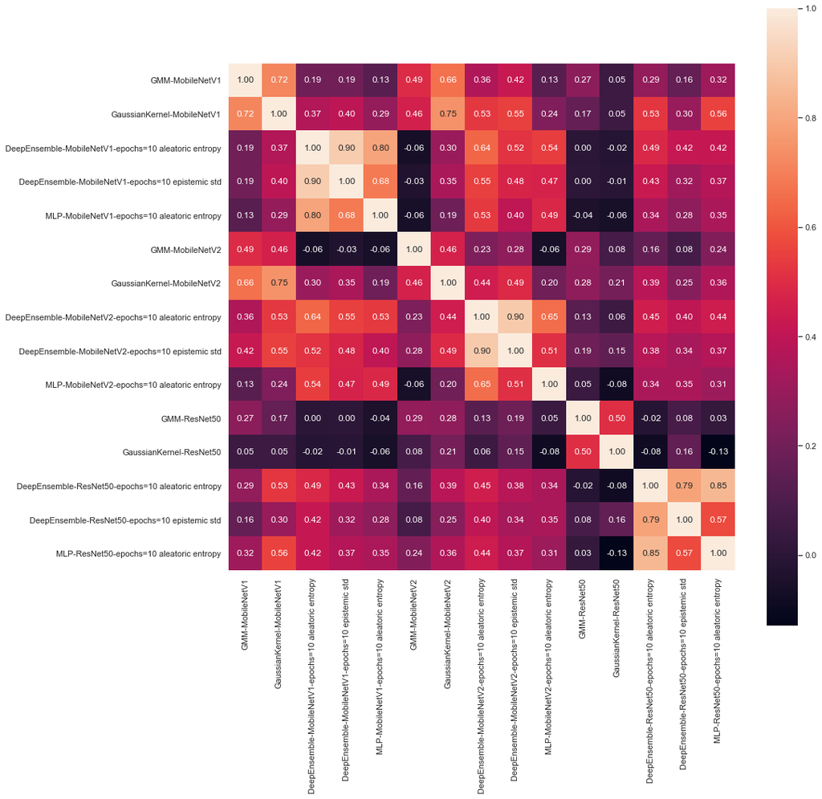

```python
import seaborn as sns; sns.set()
names_embedding = [name for name in uncertainty_scaled.keys() if "MobileNetV1" in name] +  [name for name in uncertainty_scaled.keys() if "MobileNetV2" in name] + [name for name in uncertainty_scaled.keys() if "ResNet50" in name]
fig, ax = plt.subplots(figsize=(15,15))         # Sample figsize in inches
sns.heatmap(uncertainty_scaled[names_embedding].corr(), fmt='0.2f', annot=True, square=True)
```

## Visualization of uncertain data

```python
for strat_name in uncertainty_scaled.keys():
    if strat_name not in ["GroundTruth", "UncertaintyLabel", "Images"]:

        fig = Figures.display_most_uncertain_images(uncertainty_scaled, strat_name)
        fname = open("images/{0}_{1}".format(strat_name, "uncertain.png"), "wb")
        fig.savefig(fname)

        fig = Figures.display_most_certain_images(uncertainty_scaled, strat_name)
        fname = open("images/{0}_{1}".format(strat_name, "certain.png"), "wb")
        fig.savefig(fname)
```

```python
frag = "GaussianKernel"
embedding = "MobileNetV1"
strat_name = [v for v in names_embedding if (frag in v and embedding in v)][0]
Figures.show_uncertainty(strat_name)
```

```
GaussianKernel-MobileNetV1
```

[output not shown]

```
DeepEnsemble-MobileNetV1-epochs=10 aleatoric entropy
```

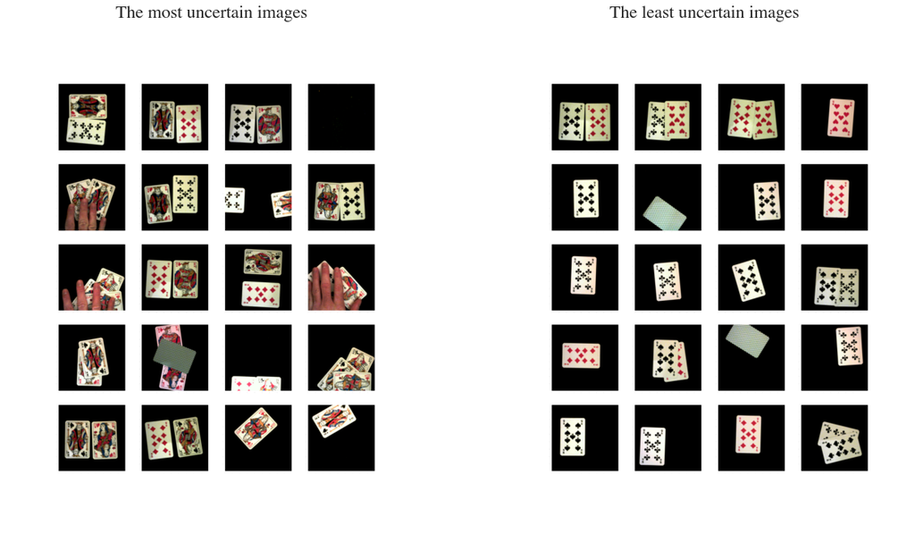

```python
frag = "entropy"
embedding = "MobileNetV1"
strat_name = [v for v in names_embedding if (frag in v and embedding in v)][0]
Figures.show_uncertainty(strat_name)
```

**Observation**: It seems that the different techniques are capturing different types of uncertainty.

### Uncertainty separation

We now try to distinguish i.i.d data from novel or ambiguous data using our uncertainity measures.

```python
res_values_OOD = []
for i in range(12):
    print("Itération", i+1, "/10")
    train, test, uncertain = Data.get_dataset(filepath = filepath,  seed = i)
    (z_train, y_train), (z_test, y_test), z_uncertain = Data.dataframe2arrays(train, test, uncertain)
    model_params = ModelUtilities.get_models_param(embeddings = ["MobileNetV1", "MobileNetV2", "ResNet50"],
                nb_mlp = [3],
                architecture = [(64,32)],
                epochs = [10],
                batch_sizes = [16],
                classes = list(range(10))
                )
    models = ModelUtilities.get_models(model_params)
    ModelUtilities.fit_models(models, z_train, y_train, verbose = False)
    z_iid  = z_test
    res_values_OOD.append(PerformanceMetrics.uncertainty_classification(models, z_iid, z_uncertain, verbose = False))

# values_OOD = PerformanceMetrics.uncertainty_classification(models, z_iid, z_uncertain, verbose = True)
# Figures.auroc(PerformanceMetrics.AUROC(values_OOD))
```

[output not shown]

[output cut: 41 more lines]

[output not shown]

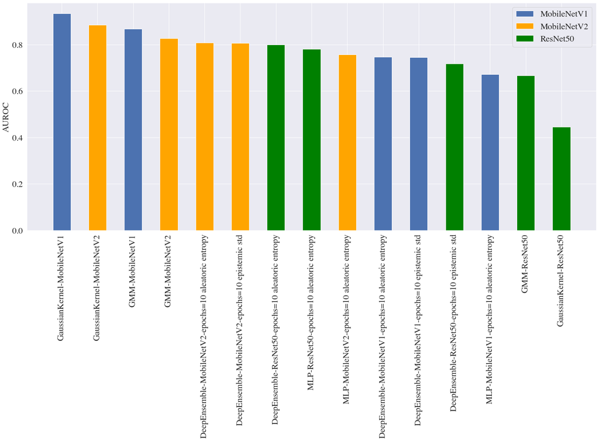

```python
auroc_tmp = {}
auroc_mean = {}
auroc_std = {}
for key in res_values_OOD[0].keys():
    auroc_tmp[key] = []
    for dic in res_values_OOD:
        auroc = PerformanceMetrics.AUROC(dic)
        auroc_tmp[key].append(auroc[key])
    auroc_mean[key] = np.mean(auroc_tmp[key])
    auroc_std[key] = np.std(auroc_tmp[key])

Figures.auroc(auroc_mean)
```

```python
import pickle
auroc_cards = {"mean": auroc_mean,
               "std": auroc_std,
               "samples": auroc_tmp}
pickle.dump(auroc_cards, open("auroc_cards_b.pkl", "wb"))
```

**Observation**: We see a smaller difference between the different technique and no prevalence ofthe embedding chosen.

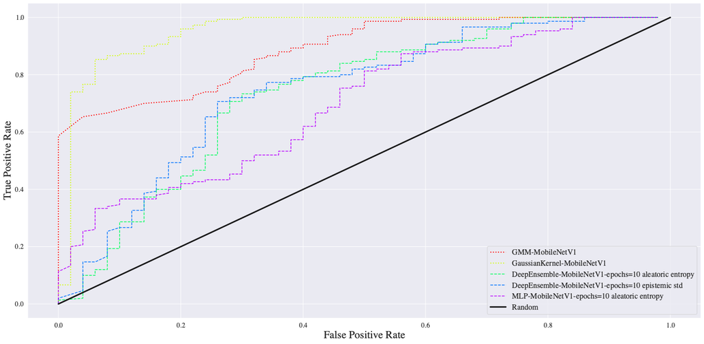

```python
Figures.roc(Data.sel_keys(res_values_OOD[0], "MobileNetV1"), "linear")
```

**Observation**: We will select Gaussian Kernel an epistemic measure for the study and keep the DE entropy for the aleatoric measure.

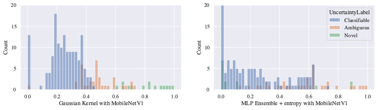

```python
strategy_names = list(uncertainty_scaled.keys())[:-4]
import matplotlib.pylab as pylab


import matplotlib
matplotlib.use('cairo')
import matplotlib.pylab as pylab
import matplotlib.font_manager as fm
font = fm.FontProperties(family = 'Gill Sans', fname = '/Library/Fonts/GillSans.ttc')

len(strategy_names)
Figures.histogram(uncertainty_scaled, model_names = ["GaussianKernel-MobileNetV1",  "DeepEnsemble-MobileNetV1-epochs=10 aleatoric entropy"], figsize= (13,7))
plt.savefig("../../figures_paper/histogram.pdf", bbox_inches = "tight")
```

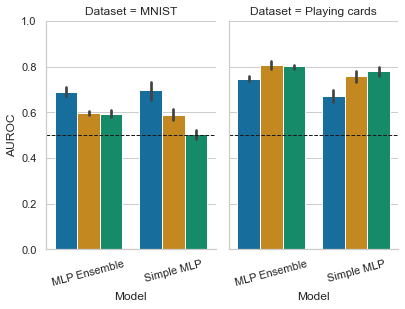

```python
g = Figures.save_auroc_paper("Aleatoric uncertainty")
```